# DSP evaluation April 2018

Pablo Porras

09/04/2018

## Synopsys

Evaluation for a DSP report tobe used in PSI and EMBO Networks meetings in Heidelberg.

#### Libraries

```r
library(data.table)
library(dplyr)
library(stringr)
library(ggplot2)
library(PSICQUIC)
```

### Evaluate how many publications contained interaction data per source

I download the information from the manual evaluation Google doc at https://docs.google.com/spreadsheets/d/1tL1HtVD3-BxHxKuXbIYhcFjmCptGVEOD5aFJCZw6CZk/edit#gid=0. This is done manually for convenience.

I put together an updated list with all evaluated publications.

##### Upload data

```r
lhf <- fread("./eval_tables/lhf_rd1.txt",
             header = T,
             sep = "\t",
             colClasses = "character",
             check.names = T,
             stringsAsFactors = F)

tm_it1 <- fread("./eval_tables/tm_it1.txt",
             header = T,
             sep = "\t",
             colClasses = "character",
             check.names = T,
             stringsAsFactors = F)

tm_it2 <- fread("./eval_tables/tm_it2.txt",
             header = T,
             sep = "\t",
             colClasses = "character",
             check.names = T,
             stringsAsFactors = F)

tm_it3 <- fread("./eval_tables/tm_it3.txt",
             header = T,
             sep = "\t",
             colClasses = "character",
             check.names = T,
             stringsAsFactors = F)

tm_it4 <- fread("./eval_tables/tm_it4.txt",
             header = T,
             sep = "\t",
             colClasses = "character",
             check.names = T,
             stringsAsFactors = F)

dsp_priority <- fread("./eval_tables/20180409_dsp_priority.txt",
             header = T,
             sep = "\t",
             colClasses = "character",
             check.names = T,
             stringsAsFactors = F)

dsp_priority_eval <- unique(dsp_priority[curatable!=""])
```

##### Process data

```r
lhf_sel <- unique(lhf[,.(contains_interactions = Contains.interactions.,
                         correct_pairs = paste(unique(Are.pairs.correct.),collapse = "|"),
                         curator = paste(unique(Curator),collapse="|")),
                      by = "pmid"])
tm_it1_sel <- unique(tm_it1[,.(contains_interactions = Contains.interactions.,
                               correct_pairs = "",
                               curator = paste(unique(Curator),collapse="|")),
                            by = "pmid"])

tm_it2_sel <- unique(tm_it2[,.(contains_interactions = Contains.interactions.,
                               correct_pairs = "",
                               curator = paste(unique(Curator),collapse="|")),
                            by = "pmid"])

tm_it3_sel <- unique(tm_it3[,.(contains_interactions = Contains.interactions.,
                               correct_pairs = "",
                               curator = paste(unique(Curator),collapse="|")),
                            by = "pmid"])

tm_it4_sel <- unique(tm_it4[,.(contains_interactions = Contains.interactions.,
                               correct_pairs = "",
                               curator = paste(unique(Curator),collapse="|")),
                            by = "pmid"])

all_pmids_eval <- unique(rbind(lhf_sel,
                               tm_it1_sel,
                               tm_it2_sel,
                               tm_it3_sel,
                               tm_it4_sel))
all_pmids_eval <- all_pmids_eval[pmid!="0"]
fwrite(all_pmids_eval,
       "./processed/all_pmids_eval.txt",
       col.names = T,
       row.names = F,
       sep = "\t",
       quote = F)
```

#### Obtain source information

```r
if(!exists("dsp_comp")){
        system("gunzip -k ../dsp_comparison/results/pubpaircomp_table_final.txt.gz")
        dsp_comp <- fread("../dsp_comparison/results/pubpaircomp_table_final.txt",
              header = T,
              colClasses = "character",
              stringsAsFactors = F)
        system("rm ../dsp_comparison/results/pubpaircomp_table_final.txt")
}
```

```
##
Read 28.7% of 2093151 rows
Read 67.8% of 2093151 rows
Read 2093151 rows and 19 (of 19) columns from 0.112 GB file in 00:00:04
```

```r
dsp_source_pmid <- unique(dsp_comp[,.(noncur_prot = paste(unique(noncur_prot),collapse="|"),
                                      imex = paste(unique(imex),collapse="|"),
                                      GO_IPI = paste(unique(GO_IPI),collapse="|"),
                                      BioGRID = paste(unique(BioGRID),collapse="|"),
                                      tm_epmc = paste(unique(tm_epmc),collapse="|"),
                                      tm_pr_times_found_total = sum(as.numeric(tm_pr_times_found)),
                                      tm_dm_times_found_total = sum(as.numeric(tm_dm_times_found)),
                                      EVEX = paste(unique(EVEX),collapse="|"),
                                      evex_score_ave = mean(as.numeric(evex_score)),
                                      STRING_textmining = paste(unique(STRING_textmining),collapse="|"),
                                      STRING_tm_score_ave = mean(as.numeric(STRING_tm_score_ave)),
                                      reactome = paste(unique(reactome),collapse="|"),
                                      OmniPath_interactions = paste(unique(OmniPath_interactions),collapse="|"),
                                      OmniPath_ptm = paste(unique(OmniPath_ptm),collapse="|"),
                                      STRING_pi = paste(unique(STRING_pi),collapse="|"),
                                      STRING_pi_score_ave = mean(as.numeric(STRING_pi_score_ave)),
                                      iid_pred = paste(unique(iid_pred),collapse="|")),
                                   by = "pmid"])

dsp_source_pmid_clean <- dsp_source_pmid %>%
  mutate_all(funs(str_replace(.,"1\\|0|0\\|1", "1")))

dsp_source_pmid_clean <- data.table(dsp_source_pmid_clean)
```

#### Check publications containing interaction data accuracy by comparison with IMEx & other interaction sources

```r
dsp_source_pmid_simple <- dsp_source_pmid_clean[,.(pmid,
                                                   int_dbs = ifelse(imex=="1" | GO_IPI == "1" | BioGRID == "1",
                                                                    "curated",
                                                                    "not curated"),
                                                   tm_epmc,
                                                   EVEX,
                                                   STRING_textmining,
                                                   reactome,
                                                   OmniPath_interactions,
                                                   OmniPath_ptm)]

dsp_source_pmid_stats <- unique(dsp_source_pmid_simple[,.(
        tm_epmc = sum(as.numeric(tm_epmc)),
        tm_evex = sum(as.numeric(EVEX)),
        tm_string = sum(as.numeric(STRING_textmining)),
        pw_reactome = sum(as.numeric(reactome)),
        pw_omnipath_ints = sum(as.numeric(OmniPath_interactions)),
        pw_omnipath_ptm = sum(as.numeric(OmniPath_ptm))
        ),
        by = "int_dbs"
        ])

dsp_source_pmid_stats_long <- melt(
   dsp_source_pmid_stats,
   id.vars = "int_dbs",
   measure.vars = c("tm_epmc","tm_evex","tm_string","pw_reactome","pw_omnipath_ints","pw_omnipath_ptm"),
   value.factor=TRUE, na.rm=TRUE
)

dsp_source_pmid_stats_wide <- dcast(
        dsp_source_pmid_stats_long,
        formula = variable ~ int_dbs,
        drop=T
)
dsp_source_pmid_stats_totals <- unique(dsp_source_pmid_stats_wide[,.(variable,
                                                                   totals = curated+`not curated`)])

dsp_source_pmid_stats_long <- unique(merge(dsp_source_pmid_stats_long,
                                           dsp_source_pmid_stats_totals,
                                           by = "variable",
                                           all = T))

dsp_source_pmid_stats_long <- dsp_source_pmid_stats_long[,perc:=round(value*100/totals,1)]
```

###### Plot overlap curated vs text-mining sources

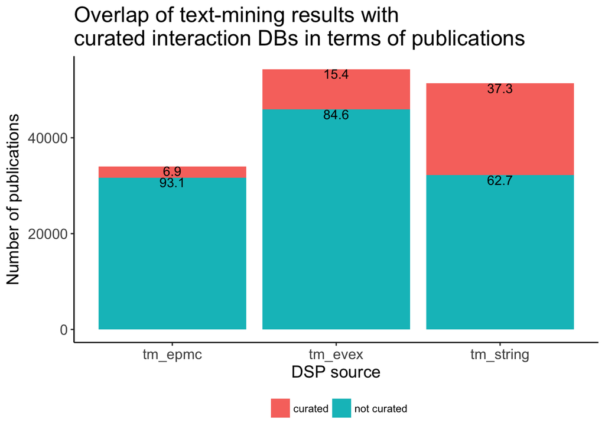

###### Plot overlap curated vs pathway DB sources

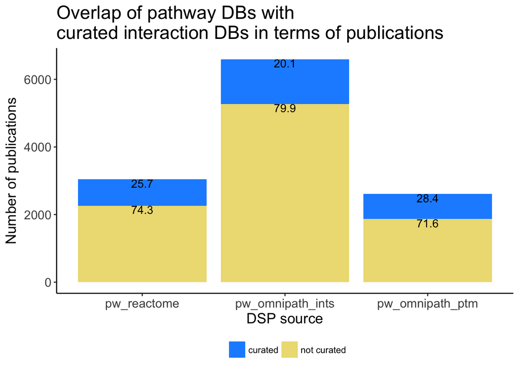

#### Check publications containing interaction data accuracy in manual evaluation

There is a number of publications that were evaluated for older tm_empc pipelines. I will discard those and the publications that have already been curated in any interaction database.

```r
man_eval_source <- unique(merge(all_pmids_eval,
                                dsp_source_pmid_simple,
                                by = "pmid",
                                all.x = T,
                                all.y = F))
man_eval_source_sel <- unique(man_eval_source[!is.na(int_dbs) & int_dbs=="not curated",
                                              .(contains_interactions = paste(unique(contains_interactions),collapse="|"),
                                                tm_epmc = paste(unique(tm_epmc),collapse="|"),
                                                tm_evex = paste(unique(EVEX),collapse="|"),
                                                tm_string = paste(unique(STRING_textmining),collapse="|"),
                                                pw_reactome = paste(unique(reactome),collapse="|"),
                                                pw_omnipath_ints = paste(unique(OmniPath_interactions),collapse="|"),
                                                pw_omnipath_ptm = paste(unique(OmniPath_ptm),collapse="|")),
                                              by = "pmid"])

man_eval_source_sel_stats <- unique(man_eval_source_sel[,.(
        tm_epmc = sum(as.numeric(tm_epmc)),
        tm_evex = sum(as.numeric(tm_evex)),
        tm_string = sum(as.numeric(tm_string)),
        pw_reactome = sum(as.numeric(pw_reactome)),
        pw_omnipath_ints = sum(as.numeric(pw_omnipath_ints)),
        pw_omnipath_ptm = sum(as.numeric(pw_omnipath_ptm))
        ),
        by = "contains_interactions"
        ])

man_eval_source_sel_stats_long <- melt(
   man_eval_source_sel_stats,
   id.vars = "contains_interactions",
   measure.vars = c("tm_epmc","tm_evex","tm_string","pw_reactome","pw_omnipath_ints","pw_omnipath_ptm"),
   value.factor=TRUE, na.rm=TRUE
)

man_eval_source_sel_stats_wide <- dcast(
        man_eval_source_sel_stats_long,
        formula = variable ~ contains_interactions,
        drop=T
)

man_eval_source_sel_stats_totals <- unique(man_eval_source_sel_stats_wide[,.(variable,
                                                                   totals = yes+no)])

man_eval_source_sel_stats_long <- unique(merge(man_eval_source_sel_stats_long,
                                           man_eval_source_sel_stats_totals,
                                           by = "variable",
                                           all = T))

man_eval_source_sel_stats_long <- man_eval_source_sel_stats_long[,perc:=round(value*100/totals,1)]
```

###### Plot accuracy text-mining sources in detecting PMIDs containing interaction data

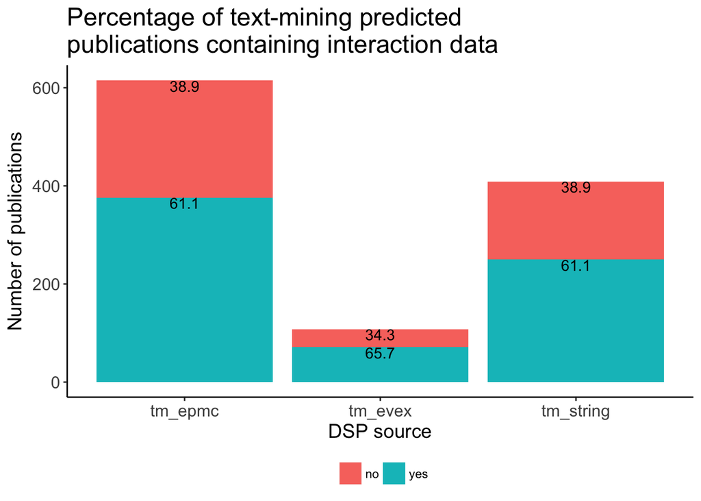

##### Non-EPMC check

These percentages are biased since the manual evaluation dataset has been selected mostly for the EPMC pipeline evaluation. Those that have not been found in this pipeline have been selected as a result of the ranking algorithm that Miguel put together. I check the percentage of correctly identified publications in EVEX and STRING_tm in those cases where no hits were found in the EPMC pipeline.

```r
man_eval_source_no_epmc <- man_eval_source[tm_epmc=="0"]

man_eval_source_no_epmc_stats <- unique(man_eval_source_no_epmc[,.(
        tm_evex = sum(as.numeric(EVEX)),
        tm_string = sum(as.numeric(STRING_textmining)),
        pw_reactome = sum(as.numeric(reactome)),
        pw_omnipath_ints = sum(as.numeric(OmniPath_interactions)),
        pw_omnipath_ptm = sum(as.numeric(OmniPath_ptm))
        ),
        by = "contains_interactions"
        ])

man_eval_source_no_epmc_stats_long <- melt(
   man_eval_source_no_epmc_stats,
   id.vars = "contains_interactions",
   measure.vars = c("tm_evex","tm_string","pw_reactome","pw_omnipath_ints","pw_omnipath_ptm"),
   value.factor=TRUE, na.rm=TRUE
)

man_eval_source_no_epmc_stats_wide <- dcast(
        man_eval_source_no_epmc_stats_long,
        formula = variable ~ contains_interactions,
        drop=T
)

man_eval_source_no_epmc_stats_totals <- unique(man_eval_source_no_epmc_stats_wide[,.(variable,
                                                                   totals = yes+no)])

man_eval_source_no_epmc_stats_long <- unique(merge(man_eval_source_no_epmc_stats_long,
                                           man_eval_source_no_epmc_stats_totals,
                                           by = "variable",
                                           all = T))

man_eval_source_no_epmc_stats_long <- man_eval_source_no_epmc_stats_long[,perc:=round(value*100/totals,1)]
```

###### Plot accuracy non-EPMC text-mining sources in detecting PMIDs containing interaction data

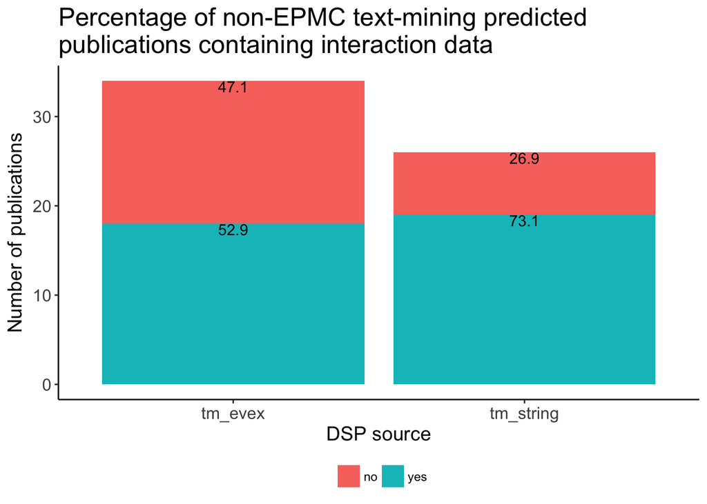

This is not very reliable due to the bias created by the algorithm and the low numbers, so best not to draw any conclusions from it.